# Part II - (The Effects of EmploymentStatus,ProsperScore and BorrowerState on LoanStatus)

## by (Lyno Kipkogei Tolo)

## Investigation Overview

In this part of the investigation,i will focus on finding out the features that are responsible for the Defaulted,Completed and Chargedoff Status of Loans. My primary focus will be EmploymentStatus,ProsperScore and BorrowerState.

## Dataset Overview

This ProsperLoan dataset contains 113,937 loans and their attributes incluning LoanStatus,BorrowerState,borrower rate (or interest rate), employment status, recommendations count, borrower income, and many others. However, i created a dataframe from a subset of LoanStatus to only include Default,Completed and Chargedoff. I also created a dummy column, CreditSCoreMean and sliced the States to the top 10 to enable my investigations

## Distribution of LoanStatus

> It is clear from the visual that majority of loans were completed with few loans defaulted.

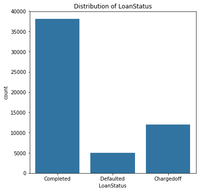

## Distribution of Employment Status

> The barplot clearly indicates that most of the borrowers are employed with majority employed full time

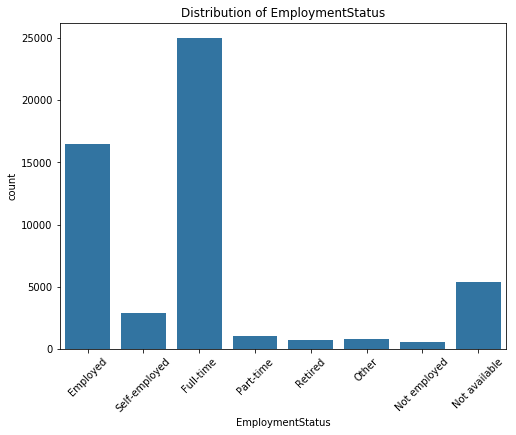

## Distribution of ProsperScore

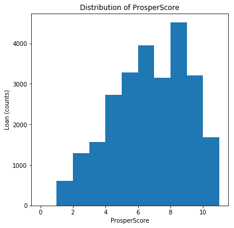

## Distribution of BorrowerState

Most of the borrowers are from the states of California, Florida, Illnois and Texas as is evident from the plot

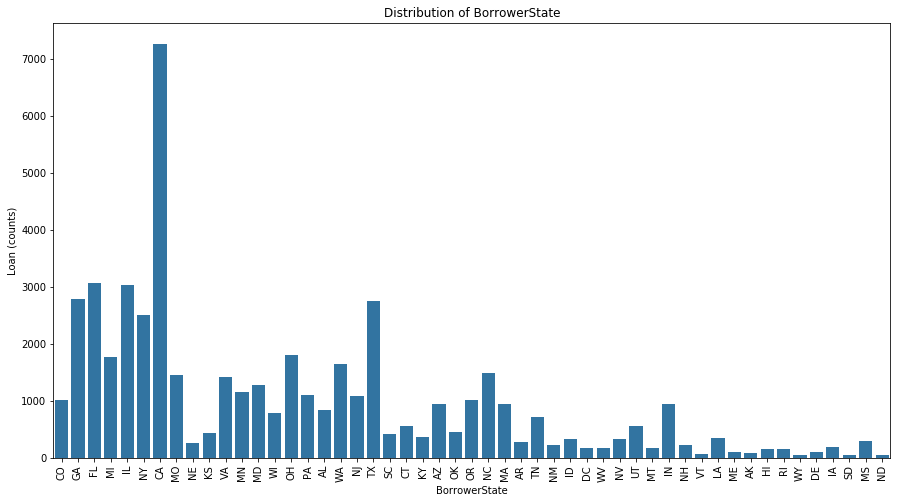

## Relationship between LoanStatus and EmploymentStatus

The barchart shows clearly that the Completed loans were the highest and this was attributed to those with a full time employment followed by those that are employed. Most of the loans were discharged off than defaulted except for the category where employment details are not available.

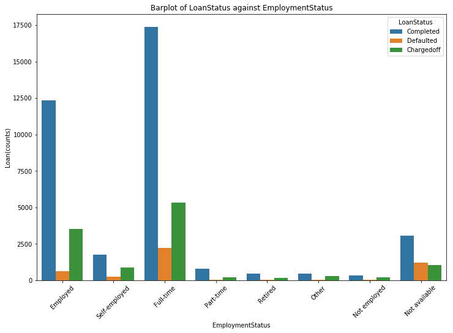

## ProsperScore relationship with LoanStatus

It is evident from the plot that the Completed loans have the highest median which drops uniformly.The high ProsperScore ratings are associated with completed loans. This implies that the ProsperScores are correct in predicting the LoanStatus with high scores correspodning to loans Completed. However, borrowers with a ProsperScore below those who Defaulted had their loans dischragedof

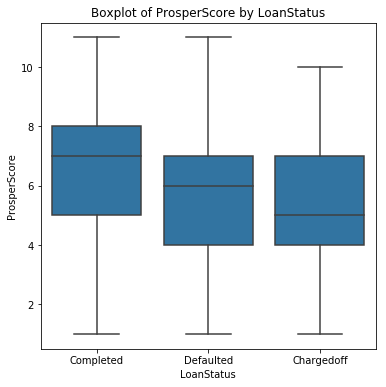

## Relationship between LoanStatus, EmploymentStatus and ProsperScore

It is evident from the plot that the borrowers who Completed their loans have a high ProsperScore regardless of their EmploymentStatus. The borrowers with who Defaulted seem to have higher ProsperScores than those with Chragedoff loans which is quite surprising.

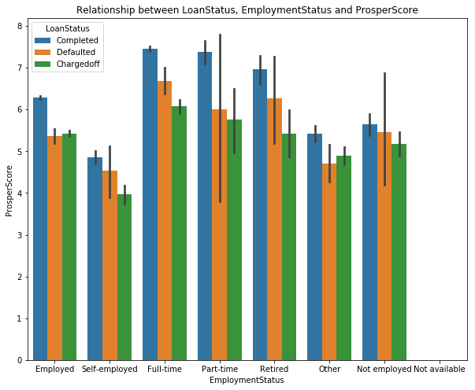

## Relationship between LoanStatus, BorrowerState and ProsperScore

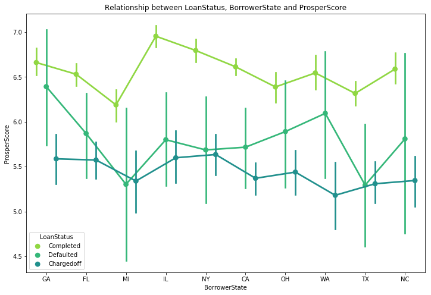